# Analysis of Sonya translatome data with IRS

This document details the analysis of proteomics data acquired to look at the translatome of cells from Sonya. All samples were run with targeted mass difference.

## Setting up the environment

These are packages you will need for this notebook. For exact versions used, please refer to the session info at the bottom of this notebook.

```r
##########################################################################################
library('tidyverse')
library('ggplot2')
library('RColorBrewer')
library('limma')
library('edgeR')
```

I want to set a base directory that we can use as a link to the directory where we will do most of the work. I use two directories here because the Workspace is what is pushed to GitHub and contains scripts and plot files, but the Repository is where more of the big data is stored that does not get pushed.

```r
##########################################################################################
generalDatasets = 'C:/Users/chughes/Documents/bccrc/projectsRepository/generalDatasets'
baseWorkspace = 'C:/Users/chughes/Documents/bccrc/projectsWorkspace/sorensenLab/relatedToOthers'
baseRepository = 'C:/Users/chughes/Documents/bccrc/projectsRepository/sorensenLab/relatedToOthers'
#generalDatasets = 'C:/Users/chris/OneDrive/Documents/bccrc/projectsRepository/generalDatasets'
#baseWorkspace = 'C:/Users/chris/OneDrive/Documents/bccrc/projectsWorkspace/sorensenLab/relatedToYbx1'
#baseRepository = 'C:/Users/chris/OneDrive/Documents/bccrc/projectsRepository/sorensenLab/relatedToYbx1'
```

## Data processing

```r
##########################################################################################
proteinSet1 = readRDS(paste(baseRepository, '/proteomics20201119_SonyaTranslationSet1Tmd/dataset_proteinSetDataset1.rds', sep = ''))
proteinSet2 = readRDS(paste(baseRepository, '/proteomics20201119_SonyaTranslationSet2Tmd/dataset_proteinSetDataset2.rds', sep = ''))
proteinSet3 = readRDS(paste(baseRepository, '/proteomics20201119_SonyaTranslationSet3Tmd/dataset_proteinSetDataset3.rds', sep = ''))
proteinSet = proteinSet1 %>%
  left_join(proteinSet2) %>%
  left_join(proteinSet3)
```

Start with the sum data and work through the IRS analysis.

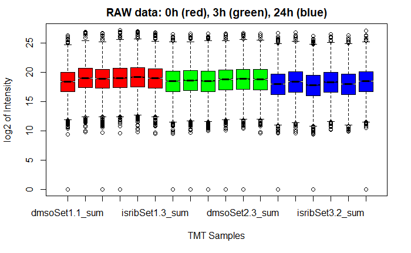

```r
##########################################################################################
rawData = proteinSet[,c(which(grepl('_sum', colnames(proteinSet))))]
rawData = rawData[,c(7,9,16,18,25,27,1:6,10:15,19:24)]
rawData[rawData == 0] = NA
rawData$accession = proteinSet$accession
rawData = subset(rawData, rowSums(is.na(rawData[,7:12])) < 6 & rowSums(is.na(rawData[,13:18])) < 6 & rowSums(is.na(rawData[,19:24])) < 6)
rawData[is.na(rawData)] = 1
##
boxplot(log2(rawData[,7:24]), col = rep(c('red', 'green', 'blue'), each = 6),
        notch = TRUE, main = 'RAW data: 0h (red), 3h (green), 24h (blue)',
        xlab = 'TMT Samples', ylab = 'log2 of Intensity')
```

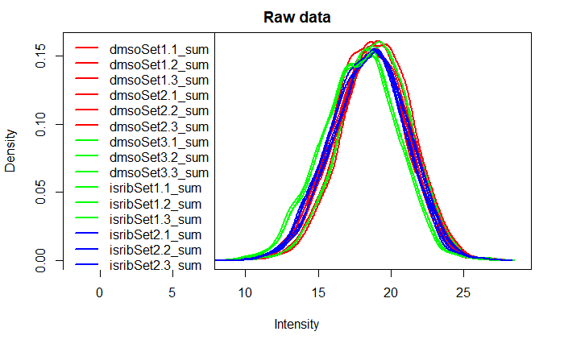

```r
##
plotDensities(log2(rawData[,7:24]), col = rep(c('red', 'green', 'blue'), each = 6),
              main = 'Raw data')
```

The data actually look pretty tight already. Check for column totals.

```r
##########################################################################################
format(round(colSums(rawData[,5:24], na.rm = TRUE), digits = 0), big.mark = ",")
```

```
heavyPoolSet3.1_sum heavyPoolSet3.2_sum      dmsoSet1.1_sum     isribSet1.1_sum      dmsoSet1.2_sum     isribSet1.2_sum      dmsoSet1.3_sum     isribSet1.3_sum
   "53,479,511,345"    "44,835,318,437"    " 4,948,912,989"    " 7,998,887,735"    " 7,120,041,721"    " 8,175,037,965"    " 8,398,851,171"    " 7,549,423,179"
     dmsoSet2.1_sum     isribSet2.1_sum      dmsoSet2.2_sum     isribSet2.2_sum      dmsoSet2.3_sum     isribSet2.3_sum      dmsoSet3.1_sum     isribSet3.1_sum
   " 5,703,908,153"    " 6,241,970,261"    " 5,716,790,455"    " 6,754,311,816"    " 7,168,640,025"    " 6,819,913,496"    " 4,280,265,218"    " 5,539,402,576"
     dmsoSet3.2_sum     isribSet3.2_sum      dmsoSet3.3_sum     isribSet3.3_sum
   " 3,726,194,128"    " 5,078,818,562"    " 4,132,887,051"    " 5,744,314,069"
```

Start off with the sample loading ‘SL’ normalization.

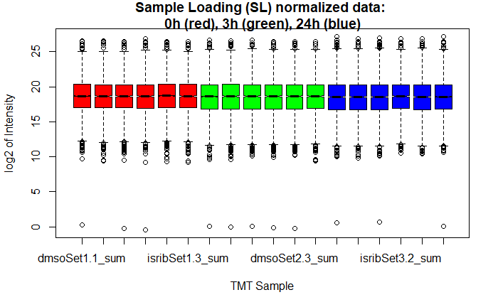

```r
##########################################################################################
# separate the TMT data by experiment
# we do not need to do this for the normalization factor calculation here,
# but we will need these data frames for the IRS step below.
exp1Raw = rawData[c(7:12)]
exp2Raw = rawData[c(13:18)]
exp3Raw = rawData[c(19:24)]

# first basic normalization is to adjust each TMT experiment to equal signal per channel
# figure out the global scaling value
target = mean(c(colSums(exp1Raw, na.rm = TRUE), colSums(exp2Raw, na.rm = TRUE), colSums(exp3Raw, na.rm = TRUE)))

# do the sample loading normalization before the IRS normalization
# there is a different correction factor for each column
normFacs = target / colSums(exp1Raw, na.rm = TRUE)
exp1Sl = sweep(exp1Raw, 2, normFacs, FUN = "*")
normFacs = target / colSums(exp2Raw, na.rm = TRUE)
exp2Sl = sweep(exp2Raw, 2, normFacs, FUN = "*")
normFacs = target / colSums(exp3Raw, na.rm = TRUE)
exp3Sl = sweep(exp3Raw, 2, normFacs, FUN = "*")

# make a pre-IRS data frame after sample loading normalizations
dataSl = cbind(exp1Sl, exp2Sl, exp3Sl)

# see what the SL normalized data look like
boxplot(log2(dataSl), col = rep(c('red', 'green', 'blue'), each = 6),
        notch = TRUE, main = "Sample Loading (SL) normalized data: \n0h (red), 3h (green), 24h (blue)",
        xlab = 'TMT Sample', ylab = 'log2 of Intensity')
```

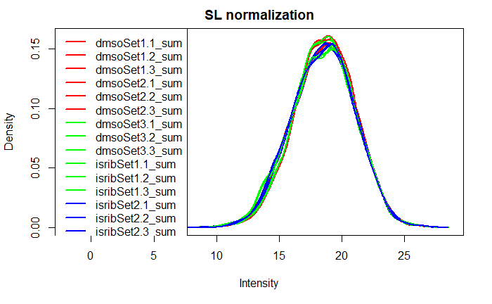

```r
# can also look at density plots (like a distribution histogram)
plotDensities(log2(dataSl), col = rep(c('red', 'green', 'blue'), each = 6), main = "SL normalization")
```

They look even tighter now. I think we can move onto IRS normalization now.

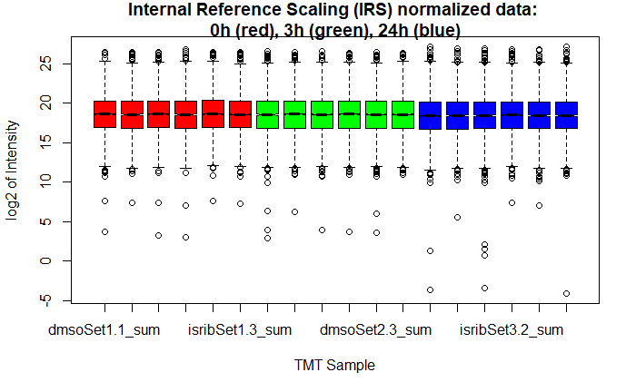

```r
##########################################################################################
# make new data frame with row sums from each frame
irs = tibble(rowSums(rawData[,1:2], na.rm = TRUE), rowSums(rawData[,3:4], na.rm = TRUE), rowSums(rawData[,5:6], na.rm = TRUE))
colnames(irs) = c('sum1','sum2','sum3')

# get the geometric average intensity for each protein
irs$average = apply(irs, 1, function(x) exp(mean(log(x),na.rm = TRUE)))

# compute the scaling factor vectors
irs$fac1 = irs$average / irs$sum1
irs$fac2 = irs$average / irs$sum2
irs$fac3 = irs$average / irs$sum3

# make new data frame with IRS normalized data
dataIrs = exp1Sl * irs$fac1
dataIrs = cbind(dataIrs, exp2Sl * irs$fac2)
dataIrs = cbind(dataIrs, exp3Sl * irs$fac3)

# see what the IRS data look like
boxplot(log2(dataIrs), col = rep(c('red', 'green', 'blue'), each = 6),
        main = "Internal Reference Scaling (IRS) normalized data: \n0h (red), 3h (green), 24h (blue)",
        xlab = 'TMT Sample', ylab = 'log2 of Intensity', notch = TRUE)
```

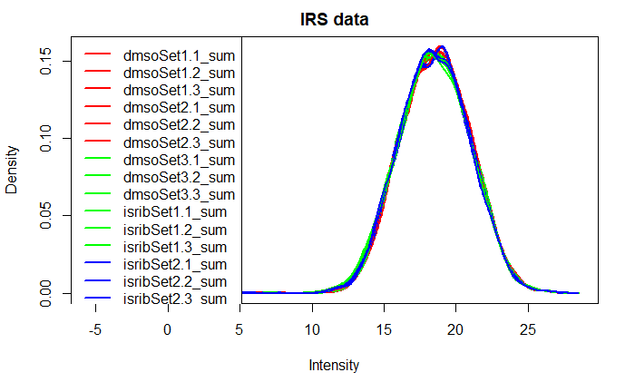

```r
# can also look at density plots (like a distribution histogram)
plotDensities(log2(dataIrs), col = rep(c('red', 'green', 'blue'), each = 6), main = "IRS data")
```

Now check the column totals again.

```r
##########################################################################################
format(round(colSums(dataIrs, na.rm = TRUE), digits = 0), big.mark = ",")
```

```
 dmsoSet1.1_sum isribSet1.1_sum  dmsoSet1.2_sum isribSet1.2_sum  dmsoSet1.3_sum isribSet1.3_sum  dmsoSet2.1_sum isribSet2.1_sum  dmsoSet2.2_sum isribSet2.2_sum
"6,260,490,056" "6,268,628,206" "6,264,123,807" "6,262,553,984" "6,257,214,704" "6,259,467,319" "5,961,968,659" "5,972,693,437" "5,973,227,870" "5,964,244,221"
 dmsoSet2.3_sum isribSet2.3_sum  dmsoSet3.1_sum isribSet3.1_sum  dmsoSet3.2_sum isribSet3.2_sum  dmsoSet3.3_sum isribSet3.3_sum
"5,958,210,134" "5,967,296,091" "5,974,682,042" "5,964,999,715" "5,976,449,165" "5,973,506,453" "5,968,335,004" "5,971,951,974"
```

Take a quick look to see how it is without TMM.

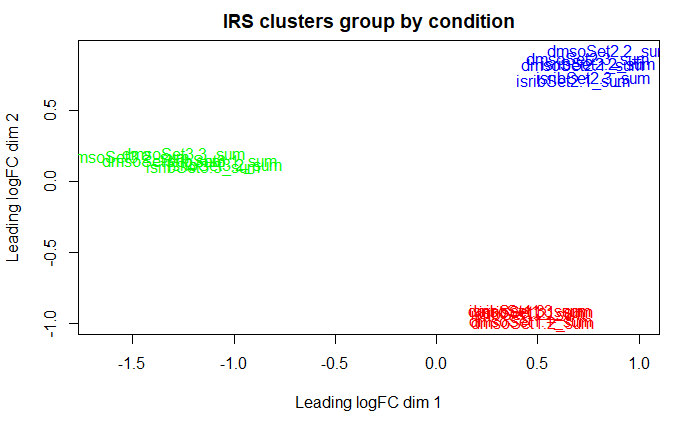

```r
##########################################################################################
# see how things cluster after IRS
colVec = c(rep('red',6),rep('blue',6),rep('green',6))
plotMDS(log2(dataIrs), col = colVec, main = "IRS clusters group by condition")
```

While this may look like they have separated by batch (they have), the batches are not technically the same, so this is not surprising. The batches are different oxygen conditions.

Recombine the data with the accessions and look at a few target proteins.

```r
##########################################################################################
proteinAnnotation = readRDS(paste(baseRepository, '/proteomics20201119_SonyaTranslationSet1Tmd/uniprotHumanNov2020.fasta.annotated.rds', sep = ''))
finalIrsData = as_tibble(cbind(rawData$accession, dataIrs)) %>%
  rename(accession = `rawData$accession`) %>%
  left_join(proteinAnnotation)
finalIrsData[grepl('HIF1A', finalIrsData$gene),]
```

| accession | dmsoSet1.1_sum | isribSet1.1_sum | dmsoSet1.2_sum | isribSet1.2_sum | dmsoSet1.3_sum | isribSet1.3_sum | dmsoSet2.1_sum | isribSet2.1_sum | dmsoSet2.2_sum | isribSet2.2_sum | dmsoSet2.3_sum | isribSet2.3_sum | dmsoSet3.1_sum | isribSet3.1_sum | dmsoSet3.2_sum | isribSet3.2_sum | dmsoSet3.3_sum | isribSet3.3_sum | gene | species | length | detectablePeptides | detectableLength |
| --- | --- | --- | --- | --- | --- | --- | --- | --- | --- | --- | --- | --- | --- | --- | --- | --- | --- | --- | --- | --- | --- | --- | --- |
| Q9NWT6 | 51531.49 | 40202.37 | 42916.17 | 42697.79 | 37516.08 | 46057.72 | 41366.35 | 34024.54 | 43444.38 | 39325.86 | 38281.91 | 37782.6 | 27355.25 | 25497.89 | 25947.54 | 24179.46 | 20128.21 | 30596.82 | HIF1AN | human | 349 | 17 | 227 |

```r
##save data
saveRDS(finalIrsData, paste(baseRepository, '/proteomics20201119_SonyaTranslationSet1Tmd/dataset_proteinSetIsribIrsNormalized.rds', sep = ''))
```

[session information not shown]